# On the differentiation between populations

J. Ignacio Lucas Lledó

2025-07-17

# Introduction

One way to visualize to what extent the two main populations can be considered two species is to compare the amount of differentiation between populations with the amount of diversity within a population. In `2024-10-10` we estimated $F_{ST}$, which suggested there is about 12.5% more diversity when comparing individuals from different populations than from the same one. But this is only one measure, based on the partition of variation within and between populations. It does not convey an intuitive meaning, and it fails to address some aspects of differentiation.

To get a more intuitive picture of differentiation, I would like to see the distribution of individual genetic differences within and between populations. Kosman, Feijen, and Jokela (2024) proposes an interesting framework, based on the distinction between *diversity* and *dispersion*, as two independent aspects of variation among populations. **Diversity** refers to how evenly separated the populations are, it is independent of the absolute magnitude of differences among them, and it is also independent of the diversity within the populations. Diversity represents the effective number of *equally distant* populations, but it is equal to 2 if there are only 2 populations. **Dispersion**, on the other hand, is related to the actual genetic distances between populations. Combined measures of diversity and dispersion constitute the effective numbers of *different* populations.

# Measures of genetic distance

The measure of genetic distance between two individuals $A$ and $B$ advocated by Kosman, Feijen, and Jokela (2024) is that of equation 6 in Kosman and Jokela (2019) for individuals of any ploidy $q$ genotyped along $n$ loci:

$$\delta_{AB} = \frac{1}{q}\times \frac{\sum_{j=1}^n
\delta_{\mathrm{min}}(A,B; j)}{n}$$

Where $\delta_{\mathrm{min}}(A, B; j)$ is the solution to the *assignment problem*, namely: matching each allele in $A$ with it’s most similar one in $B$, and adding up the differences. For diploids, $\delta_{\mathrm{min}}(A,B;j)$ is 0 if the two genotypes are the same (even if both are heterozygous); 1, if one genotype is homozygous and the other heterozygous; and 2 if they are homozygous for different alleles. For one diploid locus with two alleles, $n=1$ and $q=2$, and $\delta_{AB}$ would be like this:

|  | AA | Aa | aa |
| --- | --- | --- | --- |
| AA | 0.0 | 0.5 | 1.0 |
| Aa | 0.5 | 0.0 | 0.5 |
| aa | 1.0 | 0.5 | 0.0 |

In a probabilistic framework, we will use the `ibs` program, with `-model 0` option, which delivers the estimated percentages of each of the 100 possible genotype combinations: AA_AA, AC_AA, AG_AA… GT_TT, and TT_TT between two individuals. Thus, grouping loci by combination of genotypes, we have:

$$\delta_{AB} = \frac{1}{q}\cdot \frac{\sum_{c=AA\_AA}^{TT\_TT}n_c\cdot
\delta_{\mathrm{min}}(c)}{n} =\sum_{c=AA\_AA}^{TT\_TT}P(c)\cdot
\frac{\delta_{\mathrm{min}}(c)}{q}$$

Where $n_c$ is the number of loci with the same combination $c$ of genotypes, $P(c)$ is the frequency of the $c$ combination between those two individuals, and the summation is over the 100 possible genotype combinations. Note that genotypes are expressed in terms of actual nucleotides. I assume that `ibs` estimates the expected number of every combination of genotypes without having to infer what alleles are major and minor. There is likely no need to assume certain sites as variable, nor any need to assume variable sites are bi-allelic. This is specially important, since it means that not only drift by also mutation (if any) is contributing to the distance.

# Identity by state

I use `angsd` to get first the genotype likelihoods of the 90 individuals that were used in the NGSadmix analysis of `2024-10-05`, using only sites determined in `2025-06-12` not to be collapsed paralogs. The whole analysis is run twice: for the alignments to the reference genome and to the assembled RAD loci.

```bash
REFBAM=../2023-05-18/BAM
RADBAM=../2024-10-04/BAM
REFREF=../2023-05-15/assembly.fasta
RADREF=../2024-10-04/radloci.fa
REFSITES=../2025-06-12/ref/indH/sites.txt
RADSITES=../2025-06-12/rad/indH/sites.txt
REFCHR=../2025-06-12/ref/indH/goodchr.txt
RADCHR=../2025-06-12/rad/indH/goodchr.txt

if [ ! -d ref ]; then mkdir ref; fi
if [ ! -d rad ]; then mkdir rad; fi

if [ ! -e ref/all1.glf.gz ]; then
   if [ ! -e ref/all.list ]; then
      if [ ! -e samples.txt ]; then
         cut -f 1 ../2024-10-05/summary.txt > samples.txt
      fi
      find $REFBAM -name '*.bam' | \
      grep -f samples.txt > ref/all.list
   fi
   angsd -bam ref/all.list \
         -ref $REFREF \
         -rf  $REFCHR \
         -sites $REFSITES \
         -out ref/all1 \
         -doGlf 1 \
         -GL 1 \
         -minMapQ 30 \
         -minQ 30 \
         -only_proper_pairs 1 \
         -baq 1 \
         -minInd 75 \
         -setMinDepthInd 4 \
         -nThreads 8 1> ref/angsd1.log 2> ref/angsd1.err &
fi

if [ ! -e rad/all1.glf.gz ]; then
   if [ ! -e rad/all.list ]; then
      if [ ! -e samples.txt ]; then
         cut -f 1 ../2024-10-05/summary.txt > samples.txt
      fi
      find $RADBAM -name '*.bam' | \
      grep -f samples.txt > rad/all.list
   fi
   angsd -bam rad/all.list \
         -ref $RADREF \
         -rf  $RADCHR \
         -sites $RADSITES \
         -out rad/all1 \
         -doGlf 1 \
         -GL 1 \
         -minMapQ 30 \
         -minQ 30 \
         -only_proper_pairs 1 \
         -baq 1 \
         -minInd 75 \
         -setMinDepthInd 4 \
         -nThreads 8 1> rad/angsd1.log 2> rad/angsd1.err &
fi
wait

if [ ! -e ref/all1.ibspair ]; then
   ibs -glf ref/all1.glf.gz \
       -nInd $(cat ref/all.list | wc -l) \
       -o ref/all1 \
       -allpairs 1 \
       -model 0 1> ref/ibs.log 2> ref/ibs.err &
fi

if [ ! -e rad/all1.ibspair ]; then
   ibs -glf rad/all1.glf.gz \
       -nInd $(cat rad/all.list | wc -l) \
       -o rad/all1 \
       -allpairs 1 \
       -model 0 1> rad/ibs.log 2> rad/ibs.err &
fi
wait
```

The `ref/all1.ibspair` and `rad/all1.ibspair` tables are $4005 \times 104$, because there are $\frac{90\times 89}{2} = 4005$ pairs among 90 individuals, and 100 genotype combinations for each pair. The 4 initial columns are the 0-based indexes of the two individuals being compared, the number of sites used in the comparison and the log-likelihood.

# Genetic distances among individuals

I apply here the genetic distance defined above. The values are averages across loci, including variable and invariable loci, which I think gives a true picture of how genetically different two individuals are.

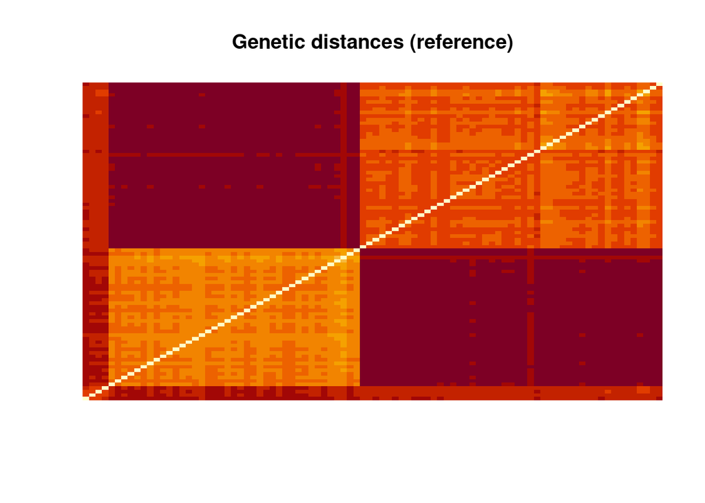

```r
library(ggplot2)
# I came up with the following way to calculate delta_min
# between two genotypes in R. Seems to work. You can check
# the result in "delta_dist.txt" file, generated below.
# x and y are vectors of alleles in two q-ploid genotypes.
# e.g.: delta.min(c('A','C'), c('G','G'))
delta.min <- function(x, y) {
   stopifnot(length(x) == length(y))
   max(sum(! x %in% y), sum(! y %in% x)) / length(x)
}

refibs <- read.table('ref/all1.ibspair', header = TRUE, na.strings = '-nan')
radibs <- read.table('rad/all1.ibspair', header = TRUE, na.strings = '-nan')
refind <- basename(scan('ref/all.list', what = 'character', quiet = TRUE))
refind <- gsub('.bam', '', refind)
radind <- basename(scan('rad/all.list', what = 'character', quiet = TRUE))
radind <- gsub('.bam', '', radind)
stopifnot(all.equal(refind, radind))
inds <- refind
rm(refind, radind)
genstr <- read.table('../2024-10-05/summary.txt', header = TRUE)
genstr$pop <- factor('admixed', levels = c('admixed', 'farionis', 'pseudofarionis'))
# Assuming K2.1 is pseudofarionis and K2.2, farionis!!
genstr[genstr$K2.1 > 0.95, 'pop'] <- 'pseudofarionis'
genstr[genstr$K2.2 > 0.95, 'pop'] <- 'farionis'
delta.c <- sapply(
   strsplit(gsub('p', '', names(refibs)[5:104]), '_', fixed = TRUE),
   function(x) {
      X <- strsplit(x, '')
      delta.min(X[[1]], X[[2]])
   }
)
names(delta.c) <- names(refibs)[5:104]
# I print the table of genetic distances to be able
# to check that the "delta.min()" function works well:
write.table(delta.c, 'delta_dist.txt', quote = FALSE, col.names = FALSE)

if (file.exists('distances.txt')) {
   distances <- read.table('distances.txt', header = TRUE)
} else {
   distances <- data.frame(
      ind1 = inds[refibs$ind1 + 1],
      ind2 = inds[refibs$ind2 + 1],
      delta_ref = sapply(
         1:dim(refibs)[1],
         function(x) {
            sum(delta.c * refibs[x, 5:104]) / (sum(refibs[x, 5:104]))
         }
      ),
      delta_rad = sapply(
         1:dim(radibs)[1],
         function(x) {
            sum(delta.c * radibs[x, 5:104]) / (sum(radibs[x, 5:104]))
         }
      ),
      pop1 = genstr[match(inds[refibs$ind1 + 1], genstr$Sample), 'pop'],
      pop2 = genstr[match(inds[refibs$ind2 + 1], genstr$Sample), 'pop']
   )
   distances$pops <- apply(
      distances[, c('pop1', 'pop2')],
      1, function(x) {paste(sort(x), collapse = '_')}
   )
   write.table(distances, file = 'distances.txt',
               quote = FALSE, row.names = FALSE)
}

# Just for the sake of printing the complete, symmetrical matrices
# of distances, first I generate the other hemimatrix:
z1 <- distances[, c('ind2', 'ind1', 'delta_ref', 'delta_rad', 'pop2', 'pop1', 'pops')]
names(z1) <- names(distances)
# I create the diagonal elements of the matrix:
zind <- unique(c(z1$ind1, z1$ind2))
di <- data.frame(
   ind1 = zind,
   ind2 = zind,
   delta_ref = 0,
   delta_rad = 0,
   pop1 = genstr[match(zind, genstr$Sample), 'pop'],
   pop2 = genstr[match(zind, genstr$Sample), 'pop'],
   pops = NA
)
zz <- rbind(distances, z1, di)
# How to order the rows is the difficult thing!
zz <- zz[order(paste0(zz$pop1, zz$ind1), paste0(zz$pop2, zz$ind2)),]
zmat.ref <- matrix(zz$delta_ref, nrow = length(zind), ncol = length(zind))
zmat.rad <- matrix(zz$delta_rad, nrow = length(zind), ncol = length(zind))

image(zmat.ref, axes = FALSE, main = 'Genetic distances (reference)')
```

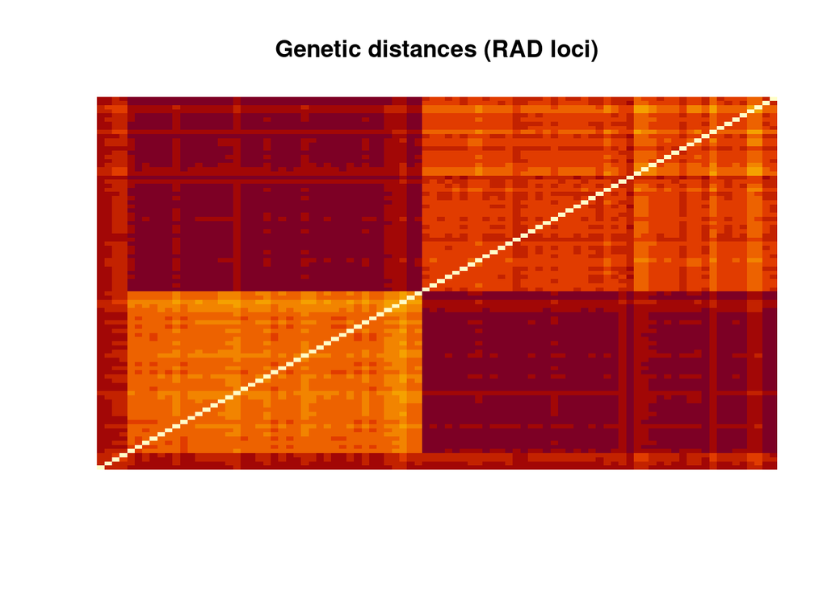

```r
image(zmat.rad, axes = FALSE, main = 'Genetic distances (RAD loci)')
```

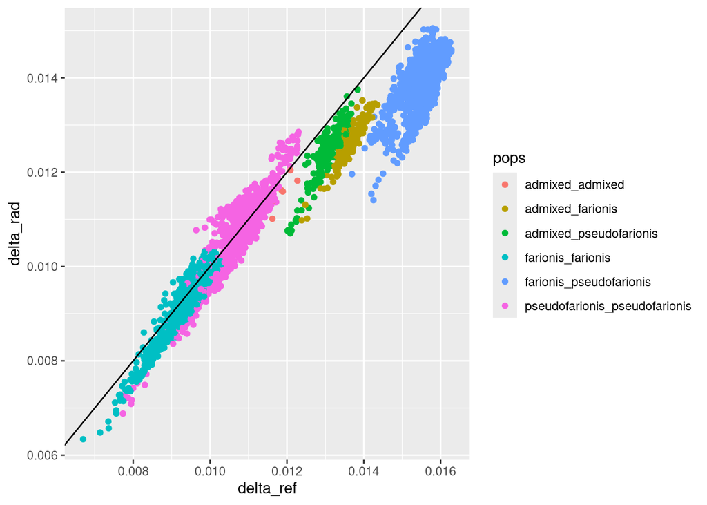

```r
ggplot(distances, aes(x = delta_ref, y = delta_rad, col = pops)) + geom_point() +
   geom_abline(intercept = 0, slope = 1)
```

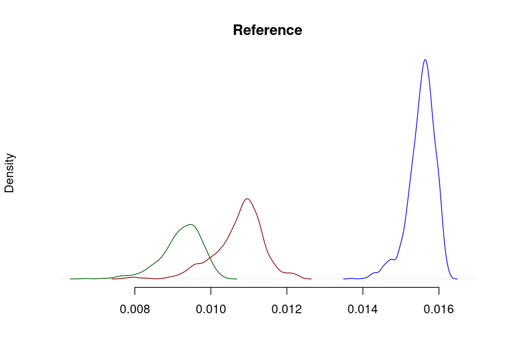

```r
fff <- distances$pops == 'farionis_farionis'
ffp <- distances$pops == 'farionis_pseudofarionis'
fpp <- distances$pops == 'pseudofarionis_pseudofarionis'

plot(density(distances$delta_ref, bw = 'SJ'), type = 'n',
     axes = FALSE, xlab = '', main = 'Reference')
lines(density(distances[fff, 'delta_ref'], bw = 'SJ',
              weights = rep(1 / length(fff), sum(fff)),
              subdensity = TRUE), col = 'darkgreen',)
lines(density(distances[fpp, 'delta_ref'], bw = 'SJ',
              weights = rep(1 / length(fpp), sum(fpp)),
              subdensity = TRUE), col = 'darkred')
lines(density(distances[ffp, 'delta_ref'], bw = 'SJ',
              weights = rep(1/ length(ffp), sum(ffp)),
              subdensity = TRUE), col = 'blue')
axis(1)
```

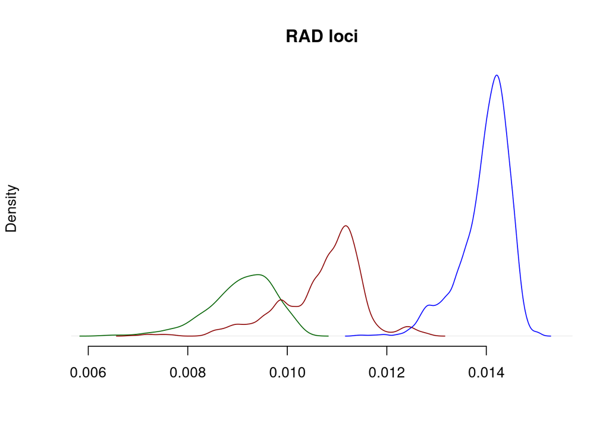

```r
plot(density(distances$delta_rad, bw = 'SJ'), type = 'n',
     axes = FALSE, xlab = '', main = 'RAD loci')
lines(density(distances[fff, 'delta_rad'], bw = 'SJ',
              weights = rep(1 / length(fff), sum(fff)),
              subdensity = TRUE), col = 'darkgreen',)
lines(density(distances[fpp, 'delta_rad'], bw = 'SJ',
              weights = rep(1 / length(fpp), sum(fpp)),
              subdensity = TRUE), col = 'darkred')
lines(density(distances[ffp, 'delta_rad'], bw = 'SJ',
              weights = rep(1/ length(ffp), sum(ffp)),
              subdensity = TRUE), col = 'blue')
axis(1)
```

# Diversity within populations

The approach used in this analysis is a *genetic method* of analysis of diversity. It is based on comparisons among individuals, using their whole genetic profile (Kosman 2014). This is different from the *genotypic methods*, which are those based on frequencies of haplotypes at one locus. And it is also different from the *gene methods*, which are based on allele frequencies at multiple loci (Nei’s gene diversity, $F_{ST}$s, and so on).

The first step in the analysis of diversity is to measure diversity within populations. I use two measures: the **average distance within** population, based on dissimilarity $\delta$ ($ADW_{\delta}$), and **Kosman’s diversity**, also based on a dissimilarity, $KW_{\delta}$.

```r
# Average Distance Within (Kosman, 2014; eq. 13): averages the whole
# matrix of distances among individuals in a population, including
# both d(i, j) and d(j, i), and distances to selves, d(i, i).
# Here, "n" is the number of individuals in the population, deduced
# from the number of pairs (length(x)).
ADW.ref <- sapply(
   c('admixed', 'farionis', 'pseudofarionis'),
   function(i) {
      x <- distances[distances$pops == paste(i, i, sep = '_'), 'delta_ref']
      n <- (1 + sqrt(1 + 8 * length(x))) / 2
      return(mean(c(x, x, rep(0, n))))
   }
)

ADW.rad <- sapply(
   c('admixed', 'farionis', 'pseudofarionis'),
   function(i) {
      x <- distances[distances$pops == paste(i, i, sep = '_'), 'delta_rad']
      n <- (1 + sqrt(1 + 8 * length(x))) / 2
      return(mean(c(x, x, rep(0, n))))
   }
)
```

Kosman’s diversity within is a bit more complicated. It consists on matching every individual in the population with its most different one, so as to maximize the sum of differences. The total number of pairs is equal to the number of individuals, the pairs are made between two copies of the population, as in the entris of an $n\times n$ matrix.

```r
library(kableExtra)
# I create the KW function to take the "distances" d.f. as input.
KW <- function(x, pop, delta = 'delta_ref') {
   x.sel <- x[x$pops %in% pop,
              c('ind1', 'ind2', delta)]
   # Eq. 14 in Kosman (2014)
   inds <- unique(c(x.sel$ind1, x.sel$ind2))
   n1 <- length(inds)
   stopifnot(nrow(x.sel) == n1 * (n1 - 1) / 2)
   # the other hemimatrix, switchin individuals
   unfold <- data.frame(
      ind1 = x.sel$ind2,
      ind2 = x.sel$ind1,
      delta = x.sel[, delta]
   )
   names(unfold)[3] <- delta
   # the diagonal elements of the complete matrix
   diagonal <- data.frame(
      ind1 = inds,
      ind2 = inds,
      delta = rep(0, length(inds))
   )
   names(diagonal)[3] <- delta
   x.sel <- rbind(
      x.sel,
      unfold,
      diagonal
   )
   # I use pivot_wider() to turn the d.f. into matrix format
   x.wide <- tidyr::pivot_wider(
      x.sel,
      id_cols = ind1,
      names_from = ind2,
      values_from = delta
   )
   class(x.wide) <- 'data.frame'
   row.names(x.wide) <- x.wide$ind1
   x.mat <- as.matrix(x.wide[, -1])
   stopifnot(nrow(x.mat) == ncol(x.mat))
   sol <- lpSolve::lp.assign(x.mat, direction = 'max')
   return(sol$objval / n1)
}


KW.ref <- c(
   admixed  = KW(distances, 'admixed_admixed', 'delta_ref'),
   farionis = KW(distances, 'farionis_farionis', 'delta_ref'),
   pseudofarionis = KW(distances, 'pseudofarionis_pseudofarionis', 'delta_ref')
)
KW.rad <- c(
   admixed  = KW(distances, 'admixed_admixed', 'delta_rad'),
   farionis = KW(distances, 'farionis_farionis', 'delta_rad'),
   pseudofarionis = KW(distances, 'pseudofarionis_pseudofarionis', 'delta_rad')
)

diversityWithin <- data.frame(
   Population = rep(c('admixed', 'C. farionis', 'C. pseudofarionis'), each = 4),
   Data = rep(rep(c('Reference', 'RAD loci'), each = 2), 3),
   Method = rep(c('ADW', 'KW'), 6),
   Diversity = c(
      ADW.ref['admixed'], KW.ref['admixed'],
      ADW.rad['admixed'], KW.rad['admixed'],
      ADW.ref['farionis'], KW.ref['farionis'],
      ADW.rad['farionis'], KW.rad['farionis'],
      ADW.ref['pseudofarionis'], KW.ref['pseudofarionis'],
      ADW.rad['pseudofarionis'], KW.rad['pseudofarionis']
   )
)
write.table(diversityWithin, 'diversityWithin.txt', quote = FALSE, row.names = FALSE)
kable(diversityWithin) %>% kable_styling(full_width = FALSE)
```

| Population | Data | Method | Diversity |
| --- | --- | --- | --- |
| admixed | Reference | ADW | 0.0089218 |
| admixed | Reference | KW | 0.0119550 |
| admixed | RAD loci | ADW | 0.0086839 |
| admixed | RAD loci | KW | 0.0116043 |
| C. farionis | Reference | ADW | 0.0089943 |
| C. farionis | Reference | KW | 0.0094096 |
| C. farionis | RAD loci | ADW | 0.0088511 |
| C. farionis | RAD loci | KW | 0.0092486 |
| C. pseudofarionis | Reference | ADW | 0.0105112 |
| C. pseudofarionis | Reference | KW | 0.0110283 |
| C. pseudofarionis | RAD loci | ADW | 0.0104846 |
| C. pseudofarionis | RAD loci | KW | 0.0109370 |

The reason why ADW and KW differ more in the admixed population is just that there are only 4 individuals there. Because ADW averages all-against-all dissimilarities, including selves, the weight of zero values is higher in smaller samples.

# Distances between populations

Distances between populations can also be measured in different ways. Below I implement the $DAD_{\delta}$ and the $KB_{\delta}$. $DAD_{\delta}$ might be negative (Kosman 2014), and must be used carefully.

```r
# Average distance between (ADB) (Kosman, 2014; eq. 15)
# Needed to get DAD.
ADB.ref <- sapply(
   split(distances$delta_ref, distances$pops),
   mean
)
ADB.rad <- sapply(
   split(distances$delta_rad, distances$pops),
   mean
)

# Distance of average differences, equation 16 in Kosman (2014):
pairs <- c('admixed_farionis', 'admixed_pseudofarionis', 'farionis_pseudofarionis')
DAD.ref <- sapply(
   pairs,
   function(x){
      pops <- unlist(strsplit(x, '_'))
      ADB.ref[x] - (ADW.ref[pops[1]] + ADW.ref[pops[2]]) / 2
   },
   USE.NAMES = FALSE
)
DAD.rad <- sapply(
   pairs,
   function(x) {
      pops <- unlist(strsplit(x, '_'))
      ADB.rad[x] - (ADW.rad[pops[1]] + ADW.rad[pops[2]]) / 2
   },
   USE.NAMES = FALSE
)
```

Kosman’s distance between populations, $KB_{\delta}$, is more complicated. We need to solve the assignment problem: for every individual in one population we have to assign one of the other, so that every individual is paired in such a way that the sum of differences is **minimized**. The assignment problem is usually framed between two sets of the same size: e.g, jobs and machines, where every job must be run in a different machine. Kosman (2014) does not specify how to proceed when one sample is larger than the other. But it seems to be common practice in operational research to augment the smallest set with dummy vertices connected with zero-cost edges to all vertices of the other set. The package that can solve the assignment problem in R is called `lpSolve`. The challenge here is to present the distances as a square matrix.

The strategy is to first extract from `distances` the rows that compare individuals from the two populations; then, switch individuals 1 and 2 as needed to have only one population per column. Then, use `pivot_wider()` from `tidyr` to distribute the distances in a matrix; and finally add the rows or columns necessary to make it squared.

```r
library(kableExtra)
KB <- function(x, pops, delta = 'delta_ref') {
   x.sel <- x[x$pops == pops,
              c('ind1', 'ind2', 'pop1', 'pop2', delta)]
   popL <- unlist(strsplit(pops, '_'))
   x.sel$indpop1 <- ifelse(
      x.sel$pop1 == popL[1],
      x.sel$ind1,
      x.sel$ind2
   )
   x.sel$indpop2 <- ifelse(
      x.sel$pop1 == popL[2],
      x.sel$ind1,
      x.sel$ind2
   )
   x.wide <- tidyr::pivot_wider(
      x.sel[, c(delta, 'indpop1', 'indpop2')],
      id_cols = 'indpop1',
      names_from = 'indpop2',
      values_from = delta
   )
   class(x.wide) <- 'data.frame'
   row.names(x.wide) <- x.wide$indpop1
   x.mat <- as.matrix(x.wide[, -1])
   n1 <- nrow(x.mat)
   n2 <- ncol(x.mat)
   if (n1 < n2) {
      x.mat <- rbind(x.mat,
                     matrix(0,
                            nrow = n2 - n1,
                            ncol = n2))
   }
   if (n1 > n2) {
      x.mat <- rbind(x.mat,
                     matrix(0,
                            nrow = n1,
                            ncol = n1 - n2))
   }
   sol <- lpSolve::lp.assign(x.mat, direction = 'min')
   return(sol$objval / min(n1, n2))
}

KB.ref <- c(
   admixed_farionis = KB(distances, 'admixed_farionis', 'delta_ref'),
   admixed_pseudofarionis = KB(distances, 'admixed_pseudofarionis', 'delta_ref'),
   farionis_pseudofarionis = KB(distances, 'farionis_pseudofarionis', 'delta_ref')
)
KB.rad <- c(
   admixed_farionis = KB(distances, 'admixed_farionis', 'delta_rad'),
   admixed_pseudofarionis = KB(distances, 'admixed_pseudofarionis', 'delta_rad'),
   farionis_pseudofarionis = KB(distances, 'farionis_pseudofarionis', 'delta_rad')
)

distancesBetween <- data.frame(
   Population_1 = rep(c('admixed', 'admixed', 'C. farionis'), each = 6),
   Population_2 = rep(c('C. farionis', 'C. pseudofarionis', 'C. pseudofarionis'), each = 6),
   Data = rep(rep(c('RAD loci', 'Reference'), each = 3), 3),
   Method = rep(c('ADB', 'DAD', 'KB'), 6),
   Distance = c(
      ADB.rad['admixed_farionis'],
      DAD.rad['admixed_farionis'],
      KB.rad['admixed_farionis'],
      ADB.ref['admixed_farionis'],
      DAD.ref['admixed_farionis'],
      KB.ref['admixed_farionis'],
      ADB.rad['admixed_pseudofarionis'],
      DAD.rad['admixed_pseudofarionis'],
      KB.rad['admixed_pseudofarionis'],
      ADB.ref['admixed_pseudofarionis'],
      DAD.ref['admixed_pseudofarionis'],
      KB.ref['admixed_pseudofarionis'],
      ADB.rad['farionis_pseudofarionis'],
      DAD.rad['farionis_pseudofarionis'],
      KB.rad['farionis_pseudofarionis'],
      ADB.ref['farionis_pseudofarionis'],
      DAD.ref['farionis_pseudofarionis'],
      KB.ref['farionis_pseudofarionis']
   )
)
kable(distancesBetween) %>% kable_styling(full_width = FALSE)
```

| Population_1 | Population_2 | Data | Method | Distance |
| --- | --- | --- | --- | --- |
| admixed | C. farionis | RAD loci | ADB | 0.0126333 |
| admixed | C. farionis | RAD loci | DAD | 0.0038658 |
| admixed | C. farionis | RAD loci | KB | 0.0118012 |
| admixed | C. farionis | Reference | ADB | 0.0136559 |
| admixed | C. farionis | Reference | DAD | 0.0046979 |
| admixed | C. farionis | Reference | KB | 0.0130479 |
| admixed | C. pseudofarionis | RAD loci | ADB | 0.0124135 |
| admixed | C. pseudofarionis | RAD loci | DAD | 0.0028292 |
| admixed | C. pseudofarionis | RAD loci | KB | 0.0111755 |
| admixed | C. pseudofarionis | Reference | ADB | 0.0130517 |
| admixed | C. pseudofarionis | Reference | DAD | 0.0033352 |
| admixed | C. pseudofarionis | Reference | KB | 0.0123454 |
| C. farionis | C. pseudofarionis | RAD loci | ADB | 0.0139814 |
| C. farionis | C. pseudofarionis | RAD loci | DAD | 0.0043135 |
| C. farionis | C. pseudofarionis | RAD loci | KB | 0.0138468 |
| C. farionis | C. pseudofarionis | Reference | ADB | 0.0155474 |
| C. farionis | C. pseudofarionis | Reference | DAD | 0.0057947 |
| C. farionis | C. pseudofarionis | Reference | KB | 0.0154259 |

```r
write.table(distancesBetween, 'distancesBetween.txt', row.names = FALSE,
            quote = FALSE, sep = '\t')
```

$DAD_{\delta}$ may not be appropriate if there is linkage disequilibrium among markes, but if it is bounded between 0 and 1 (not sure about that), then it can be used to build metrics of diversity, just as well as $KB_{\delta}$.

# Diversity

Here, I follow Kosman, Feijen, and Jokela (2024), where *diversity* is understood as how evenly distributed the populations are, or how regular distances among them are. This only makes sense for more than two populations. I have been considering the four admixed individuals as a third population mostly to test the formulas of diversity. But this section is irrelevant because we are using data from only two biologically plausible populations.

```r
# Eq. 2 in Kosman et al. 2024.
# Note that distances are counted twice
f <- list(
   dad.ref = DAD.ref / (2 * sum(DAD.ref)),
   dad.rad = DAD.rad / (2 * sum(DAD.rad)),
   kb.ref  = KB.ref / (2 * sum(KB.ref)),
   kb.rad  = KB.rad / (2 * sum(KB.rad))
)
H <- sapply(f, function(x) exp(-sum(x * log(x))))

# Eq. 3 in Kosman et al. 2024.
D <- (1 + sqrt(1 + 4 * H)) / 2
D
```

```
##  dad.ref  dad.rad   kb.ref   kb.rad
## 2.133968 2.137500 2.141292 2.141428
```

```r
# Eq. 4 in Kosman et al. 2024:
S <- 3
E <- D / S

# Eq. 4' in Kosman et al. 2024:
S  <- 3
Ep <- (D - 1) / (S - 1)
Ep
```

```
##   dad.ref   dad.rad    kb.ref    kb.rad
## 0.5669839 0.5687498 0.5706461 0.5707140
```

$D$ is the *diversity* of order 1 among the three populations, and it is to be interpreted as the effective number of *equally distant* populations. Because the admixed *population* is closer to *C. pseudofarionis*, the values are closer to 2 than to 3.

$E'$ is the evenness of order 1, in a scale from 0 to 1. The three populations are over half as evenly distant as they could be.

These are not interesting measures, because the admixed population is not a population of interest. If we exclude it, however, we are left with a number of populations $S = 2$, where evenness is 1 and the effective number of equally distant populations is necessarily 2.

# Dispersion

This corresponds with equations 6 and 6’ in Kosman, Feijen, and Jokela (2024), and with Kosman’s assignment-based measure (like in equation 14 of Kosman (2014), but with distances among populations).

```r
ADW.pop <- c(
   dad.ref = mean(c(DAD.ref, DAD.ref, rep(0, 3))),
   dad.rad = mean(c(DAD.rad, DAD.rad, rep(0, 3))),
   kb.ref  = mean(c(KB.ref, KB.ref, rep(0, 3))),
   kb.rad  = mean(c(KB.rad, KB.rad, rep(0, 3)))
)
ADW.pop.p <- (S / (S - 1)) * ADW.pop
KW.3 <- function(d) {
   m <- matrix(c(0, d[1], d[2], 0, 0, d[3], 0, 0, 0), ncol = 3)
   s <- lpSolve::lp.assign(m, direction = 'max')
   return(s$objval / 3)
}
KW.pop  <- c(
   dad.ref = KW.3(DAD.ref),
   dad.rad = KW.3(DAD.rad),
   kb.ref  = KW.3(KB.ref),
   kb.rad  = KW.3(KB.rad)
)
dispersion <- data.frame(
   Data = rep(c('Reference', 'RAD loci'), each = 6),
   Distance = rep(rep(c('DAD', 'KB'), each = 3), 2),
   Method = rep(c('ADW', 'ADWp', 'KW'), 4),
   Dispersion = c(
      ADW.pop['dad.ref'], ADW.pop.p['dad.ref'], KW.pop['dad.ref'],
      ADW.pop['kb.ref'],  ADW.pop.p['kb.ref'],  KW.pop['kb.ref'],
      ADW.pop['dad.rad'], ADW.pop.p['dad.rad'], KW.pop['dad.rad'],
      ADW.pop['kb.rad'],  ADW.pop.p['kb.rad'],  KW.pop['kb.rad']
   )
)
kable(dispersion) %>% kable_styling(full_width = FALSE)
```

| Data | Distance | Method | Dispersion |
| --- | --- | --- | --- |
| Reference | DAD | ADW | 0.0030728 |
| Reference | DAD | ADWp | 0.0046093 |
| Reference | DAD | KW | 0.0034975 |
| Reference | KB | ADW | 0.0090709 |
| Reference | KB | ADWp | 0.0136064 |
| Reference | KB | KW | 0.0094912 |
| RAD loci | DAD | ADW | 0.0024464 |
| RAD loci | DAD | ADWp | 0.0036695 |
| RAD loci | DAD | KW | 0.0027264 |
| RAD loci | KB | ADW | 0.0081830 |
| RAD loci | KB | ADWp | 0.0122745 |
| RAD loci | KB | KW | 0.0085493 |

```r
write.table(dispersion, 'dispersion.txt', quote = FALSE, sep = '\t', row.names = FALSE)
```

With only 2 populations, dispersion would be equal to the corresponding distance between the two populations.

# Effective number of different populations

Considering $S=3$:

```r
S <- 3
ENDP.ADW <- 1 + (S - 1) * E * ADW.pop.p
ENDP.ADW
```

```
##  dad.ref  dad.rad   kb.ref   kb.rad
## 1.006557 1.005229 1.019423 1.017523
```

```r
ENDP.KW  <- 1 + (S - 1) * E * KW.pop
ENDP.KW
```

```
##  dad.ref  dad.rad   kb.ref   kb.rad
## 1.004976 1.003885 1.013549 1.012205
```

When we ignore the admixed, and $S=2$, then:

```r
ADW.pop <- c(
   dad.ref = mean(c(DAD.ref[3], DAD.ref[3], rep(0, 2))),
   dad.rad = mean(c(DAD.rad[3], DAD.rad[3], rep(0, 2))),
   kb.ref  = mean(c(KB.ref[3], KB.ref[3], rep(0, 2))),
   kb.rad  = mean(c(KB.rad[3], KB.rad[3], rep(0, 2)))
)
S <- 2
ADW.pop.p <- (S / (S - 1)) * ADW.pop
KW.2 <- function(d) {
   m <- matrix(c(0, d[1], d[1], 0), ncol = 2)
   s <- lpSolve::lp.assign(m, direction = 'max')
   return(s$objval / 2)
}
KW.pop  <- c(
   dad.ref = KW.2(DAD.ref[3]),
   dad.rad = KW.2(DAD.rad[3]),
   kb.ref  = KW.2(KB.ref[3]),
   kb.rad  = KW.2(KB.rad[3])
)

E <- 1

ENDP.ADW <- 1 + (S - 1) * E * ADW.pop.p
ENDP.ADW
```

```
##  dad.ref  dad.rad   kb.ref   kb.rad
## 1.005795 1.004314 1.015426 1.013847
```

```r
ENDP.KW  <- 1 + (S - 1) * E * KW.pop
ENDP.KW
```

```
##  dad.ref  dad.rad   kb.ref   kb.rad
## 1.005795 1.004314 1.015426 1.013847
```

# Other measures of diversity

The effective number of different populations estimated above is a measure of $\beta$-diversity that is independent of total or $\gamma$-diversity and also independent of the amount of diversity within populations ($\alpha$-diversity). A more classical approach decomposes total diversity in those other two components, so that $\beta$-diversity becomes defined by the difference between total and average within diversities.

Kosman, Feijen, and Jokela (2024) (equation 18 and 20) suggests two measures of differentiation susceptible of being decomposed this way: either the Kosman’s assignment-based index ($KW_{\delta}$), or the average difference within (the total population), $ADW_{\delta}$. But it warns that the *concavity* of $ADW_{\delta}$ is not proved (it depends on the specific dissimilarity measure, $\delta$), and could not be valid.

```r
N <- length(unique(c(distances$ind1, distances$ind2)))
stopifnot(dim(distances)[1] == N * (N - 1) / 2)
TotalDiversity <- c(
   ref.adw = mean(c(distances$delta_ref,
                    distances$delta_ref,
                    rep(0, N))),
   ref.kw = KW(distances, unique(distances$pops), 'delta_ref'),
   rad.adw = mean(c(distances$delta_rad,
                    distances$delta_rad,
                    rep(0, N))),
   rad.kw = KW(distances, unique(distances$pops), 'delta_rad')
)
N <- table(genstr$pop)
AverageWithin <- c(
   ref.adw = weighted.mean(ADW.ref, N),
   ref.kw  = weighted.mean(KW.ref,  N),
   rad.adw = weighted.mean(ADW.rad, N),
   rad.kw  = weighted.mean(KW.rad,  N)
)
BetaDiversity <- TotalDiversity - AverageWithin
ST <- BetaDiversity / TotalDiversity
DiversityAnalysis <- cbind(TotalDiversity, BetaDiversity, AverageWithin, ST)
kable(DiversityAnalysis) %>% kable_styling(full_width = FALSE)
```

|  | TotalDiversity | BetaDiversity | AverageWithin | ST |
| --- | --- | --- | --- | --- |
| ref.adw | 0.0127416 | 0.0029584 | 0.0097832 | 0.2321845 |
| ref.kw | 0.0152814 | 0.0049133 | 0.0103681 | 0.3215235 |
| rad.adw | 0.0119292 | 0.0022325 | 0.0096967 | 0.1871466 |
| rad.kw | 0.0138493 | 0.0036142 | 0.0102350 | 0.2609695 |

```r
write.table(DiversityAnalysis, 'DiversityAnalysis.txt', sep = '\t', quote = FALSE)
```

The last column in the table above represents “proportional amount of variation among populations” (Kosman 2014, eq. 22), analog to the $F_{ST}$.

# Conclusions

The effective number of different populations strongly supports the idea that they are all the same species.

# References

Kosman, E. 2014. “Measuring Diversity: From Individuals to Populations.” *Eur. J. Plant Pathol.* 138: 467–86. https://doi.org/10.1007/s10658-013-0323-3.

Kosman, E., F. Feijen, and J. Jokela. 2024. “Effective Number of Different Populations: A New Concept and How to Use It.” *Ecology and Evolution* 14 (9): e70303. https://doi.org/10.1002/ece3.70303.

Kosman, E., and J. Jokela. 2019. “Dissimilarity of Individual Microsatellite Profiles Under Different Mutation Models: Empirical Approach.” *Ecology and Evolution* 9 (7): 4038–54. https://doi.org/10.1002/ece3.5032.